# Code Challenge

Jonathan Liu

October 3, 2016

## Load file & packages

```r
library(dplyr) # Data manipulation
library(caTools) # Splitting
# Decision tree
library(rpart)
library(rpart.plot)
library(rattle)
# Random forest
library(randomForest)

loan_data <- read.csv('LoanData.csv')
loan_data$last_cleared_payment_date <- as.Date(loan_data$last_cleared_payment_date)
```

# Section 1

#### Sanitary check

```r
summary(loan_data)
```

```
##       as_of_date  days_delinquent_old days_delinquent_new
##  2012-11-01:477   Min.   :  1.00      Min.   :  0.00
##                   1st Qu.:  4.00      1st Qu.:  5.00
##                   Median : 14.00      Median : 22.00
##                   Mean   : 26.66      Mean   : 32.55
##                   3rd Qu.: 38.00      3rd Qu.: 51.00
##                   Max.   :180.00      Max.   :180.00
##
##  new_outstanding_principal_balance initial_loan_amount      fico
##  Min.   :    -0.15                 Min.   :  6000      Min.   :501.0
##  1st Qu.:  7771.34                 1st Qu.: 15000      1st Qu.:591.0
##  Median : 15817.58                 Median : 25000      Median :641.0
##  Mean   : 21406.54                 Mean   : 31448      Mean   :637.3
##  3rd Qu.: 29222.66                 3rd Qu.: 40000      3rd Qu.:683.0
##  Max.   :125000.00                 Max.   :135000      Max.   :806.0
##                                                        NA's   :1
##                          sales_channel__c                  type
##  Direct                          : 74     Loan - New Customer:352
##  FAP: Managed Application Program:370     Loan - Renewal     :125
##  Promontory                      :  1
##  Referral                        : 32
##
##
##
##             current_collection_method      term        lender_payoff
##  ACH Pull                :423         Min.   : 3.000   Min.   :    0
##  Split Funding           : 35         1st Qu.: 6.000   1st Qu.:    0
##  Transfer Account Vendors: 19         Median : 6.000   Median :    0
##                                       Mean   : 8.205   Mean   : 1375
##                                       3rd Qu.:12.000   3rd Qu.:    0
##                                       Max.   :18.000   Max.   :38691
##
##  average_bank_balance__c last_cleared_payment_date
##  Min.   :   357.1        Min.   :2010-12-24
##  1st Qu.:  2967.1        1st Qu.:2012-10-03
##  Median :  5717.4        Median :2012-10-31
##  Mean   : 11632.2        Mean   :2012-10-06
##  3rd Qu.: 11103.0        3rd Qu.:2012-11-01
##  Max.   :340080.2        Max.   :2012-11-01
##  NA's   :1
```

#### Check outliers

```r
# Check number of negative cases
table(loan_data$new_outstanding_principal_balance < 0)
```

```
##
## FALSE  TRUE
##   476     1
```

#### Only one negative record was found. It’s safe to print out all outliers(2 NAs and 1 negative value) to check the pattern.

```r
filter(loan_data, !complete.cases(loan_data) | new_outstanding_principal_balance < 0)
```

```
##   as_of_date days_delinquent_old days_delinquent_new
## 1 2012-11-01                 180                 180
## 2 2012-11-01                   2                   1
## 3 2012-11-01                  97                   0
##   new_outstanding_principal_balance initial_loan_amount fico
## 1                           1409.18               25000   NA
## 2                          17951.49               35000  668
## 3                             -0.15               20000  569
##                   sales_channel__c                type
## 1 FAP: Managed Application Program      Loan - Renewal
## 2 FAP: Managed Application Program Loan - New Customer
## 3 FAP: Managed Application Program      Loan - Renewal
##   current_collection_method term lender_payoff average_bank_balance__c
## 1                  ACH Pull    6             0                10393.84
## 2                  ACH Pull    6             0                      NA
## 3                  ACH Pull    6             0                12279.94
##   last_cleared_payment_date
## 1                2012-09-17
## 2                2012-11-01
## 3                2012-06-14
```

#### Through manual inspection, mssing values shows no special pattern. Given that those outliers are very minor cases, those two incomplete cases were dropped. The outlier with negative value seems like a extreme case and cannot be generalized in this analysis, therefore it was also dropped.

```r
loan_data_clean <- filter(loan_data,
                          complete.cases(loan_data) &
                            new_outstanding_principal_balance >= 0)
```

#### Cut **days_delinquent_old** and **days_delinquent_new**

```r
groups <- c(0, 1, 5, 10, 30, 60, Inf)
cut_label <- c('0', '1-5', '5-10', '10-30', '30-60', '60+')
de_groups_old <- cut(loan_data_clean$days_delinquent_old,
                     breaks = groups,
                     include.lowest = T, right = F,
                     labels = cut_label)
de_groups_new <- cut(loan_data_clean$days_delinquent_new,
                     breaks = groups,
                     include.lowest = T, right = F,
                     labels = cut_label)
```

## Make Transition Probability Matrix

```r
# Transition frequency matrix
freq_mat <- table(de_groups_old, de_groups_new)
# Devide frequencies by row sum to get transition probability matrix
trans_mat <- freq_mat / rowSums(freq_mat)
round(trans_mat, 2) ## Item (i, j) represents the probability of a loan's movement from group i to group j
```

```
##              de_groups_new
## de_groups_old    0  1-5 5-10 10-30 30-60  60+
##         0
##         1-5   0.21 0.41 0.12  0.25  0.00 0.00
##         5-10  0.06 0.03 0.38  0.53  0.00 0.00
##         10-30 0.08 0.00 0.02  0.38  0.53 0.00
##         30-60 0.06 0.00 0.00  0.00  0.47 0.48
##         60+   0.15 0.00 0.00  0.00  0.00 0.85
```

## Make Weighted Transition Probability Matrix

```r
# Calculate sum(new_outstanding_principal_balance) for each group as weight
groups_sum <- group_by(cbind(loan_data_clean, de_groups_old, de_groups_new),
                      de_groups_old, de_groups_new) %>%
  summarize(group_sum = sum(new_outstanding_principal_balance)) %>%
  xtabs(group_sum ~ de_groups_old + de_groups_new, data = .)
# Multiply transition probabilities by weight to get weighted transition frequency matrix
wt <- trans_mat * (groups_sum / rowSums(groups_sum))
round(wt / rowSums(wt), 2) ## Item (i, j) represents the probability of movement from group i to group j, weighted by total outstanding principal balance for each group
```

```
##              de_groups_new
## de_groups_old    0  1-5 5-10 10-30 30-60  60+
##         0
##         1-5   0.14 0.56 0.05  0.25  0.00 0.00
##         5-10  0.00 0.00 0.35  0.64  0.00 0.00
##         10-30 0.00 0.00 0.00  0.36  0.64 0.00
##         30-60 0.00 0.00 0.00  0.00  0.49 0.51
##         60+   0.01 0.00 0.00  0.00  0.00 0.99
```

# Section 2

#### The target is to distinguish loans whose delinquencies are likely to worsen from ones that are likely to improve, which means this should be considered as a classification problem (Regression on the changes in delinquent days is still doable, but since the actual delinquency count is discrete, thus it does not meet the assumption of regression algorithms).

#### There are three classes in this case (loans that improved, worsen, or unchanged), we need to consider how to deal with unchanged delinquencies.

#### Check how many records has unchanged delinquency rates

```r
table(loan_data_clean$days_delinquent_old != loan_data_clean$days_delinquent_new)
```

```
##
## FALSE  TRUE
##    97   377
```

#### The unchanged group represents more than 20% of total records, it is quite risky to discard the unchanged records, because it will drop the information about this class, and cause the model to have high bias. Thus we need to keep this group, and logistic regression might not be a good choice for this problem because each logistic regression model can only do binary classification.

## Feature Engineering

#### 2. Initial loan amount and outstanding principal balance are by definition highly correlated. It can be transformed into a single variable, which indicates the payment amounts that have been made.

```r
loan_data_labeled <- loan_data_clean %>%
  mutate(delinquency_change = 'unchange') %>%
  mutate(days_since_pay = as.integer(as.Date('2012-11-01') - last_cleared_payment_date)) %>%
  mutate(paid_amount = initial_loan_amount - new_outstanding_principal_balance) %>%
  select(-c(days_delinquent_new, as_of_date, last_cleared_payment_date,
            initial_loan_amount, new_outstanding_principal_balance))

de_change <- loan_data_clean$days_delinquent_old - loan_data_clean$days_delinquent_new
loan_data_labeled$delinquency_change[de_change > 0] <- 'improve'
loan_data_labeled$delinquency_change[de_change < 0] <- 'worsen'
loan_data_labeled$delinquency_change <- as.factor(loan_data_labeled$delinquency_change)
```

## 80/20 Splitting

#### Split data into 80% training and 20% testing sets using stratified splitting based on target variable (change of delinquency)

```r
set.seed(1024)
sp <- sample.split(loan_data_labeled$delinquency_change, SplitRatio = .8)
```

## Majority voting benchmark

#### By simply predicting the outcome of all loans as the most popular case, the prediction can reach 0.66 accuracy rate. Any model that scores worse than 0.66 would be considered useless.

```r
# Check distribution of target label
voting <- table(loan_data_labeled$delinquency_change)
# Accuracy rate by simply predicting majority label
max(voting) / sum(voting)
```

```
## [1] 0.6624473
```

## Decision tree model

#### The simple decision tree model can be easily interpreted, thus it was used as the first model. The max depth of this tree has been set to 3 to avoid overfitting

#### Train decision tree model & evaluate performance

```r
loan.tree <- rpart(delinquency_change ~ .,
                   parms = list(split = 'gini'),
                   control = list(maxdepth = 3),
                   data = loan_data_labeled[sp, ])

# Performance check - Training set
pred.tree.train <- predict(loan.tree, newdata = loan_data_labeled[sp, ])
pred.tree.train.label <- apply(pred.tree.train, 1, which.max)
mean(pred.tree.train.label == as.integer(loan_data_labeled$delinquency_change[sp]))
```

```
## [1] 0.7546174
```

```r
# Performance check - Testing set
pred.tree.test <- predict(loan.tree, newdata = loan_data_labeled[!sp, ])
pred.tree.test.label <- apply(pred.tree.test, 1, which.max)
mean(pred.tree.test.label == as.integer(loan_data_labeled$delinquency_change[!sp]))
```

```
## [1] 0.7473684
```

#### The simple decision tree has achieved around 75% accuracy rate in both training and testing sets

#### Visualize & Interpret the model

```r
loan.tree$variable.importance
```

```
##            days_since_pay current_collection_method
##                 44.134694                 17.751697
##       days_delinquent_old                      term
##                 14.890028                 12.918406
##               paid_amount                      fico
##                  8.169765                  2.962294
##   average_bank_balance__c             lender_payoff
##                  2.260859                  1.233273
```

[figure not shown]

```r
fancyRpartPlot(loan.tree)
```

#### It is very easy to interpret this decision tree model by following the splitting logic at each node. For example, if the loan has not been paid within 1 day, but not more than 195 days, it is likely to worsen; however, if the unpaid days has exceeded 195 days, it is likely to improve.

## Random Forest

#### More advanced tree models tend to have better performances, but many of them require hyperparameter tuning, which is very time-consuming. Random Forest is known as having good “out of box” performance, which is ideal for this analysis.

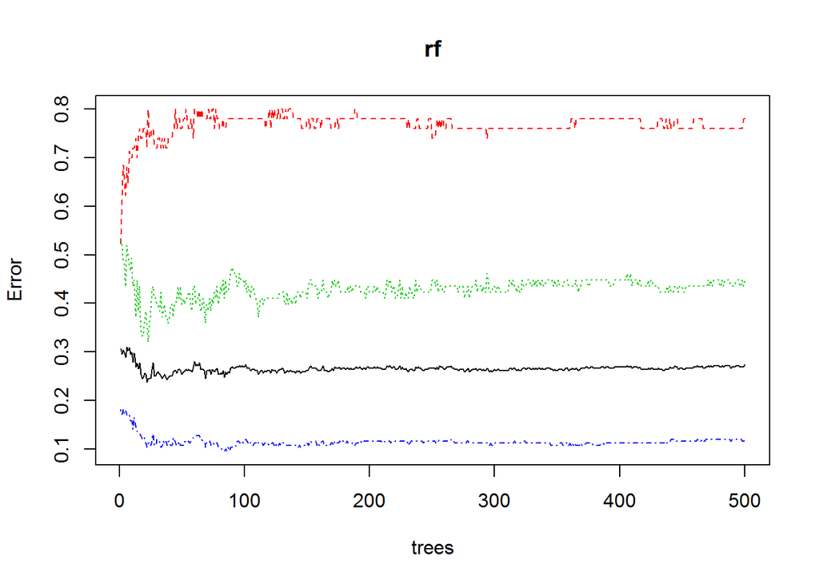

```r
set.seed(42)
rf <- randomForest(delinquency_change ~ ., data = loan_data_labeled[sp, ])

# Visualize RF performance
plot(rf)
```

```r
# Training set accuracy
mean(predict(rf, newdata = loan_data_labeled[sp, ]) == loan_data_labeled$delinquency_change[sp])
```

```
## [1] 1
```

```r
# Testing set accuracy
mean(predict(rf, newdata = loan_data_labeled[!sp, ]) == loan_data_labeled$delinquency_change[!sp])
```

```
## [1] 0.7578947
```

#### The initial RF model with default setting was severely overfitting with a 1.0 accuracy rate on the training set and 0.76 on testing set. Let’s try increase nodesides to make the model more generalized

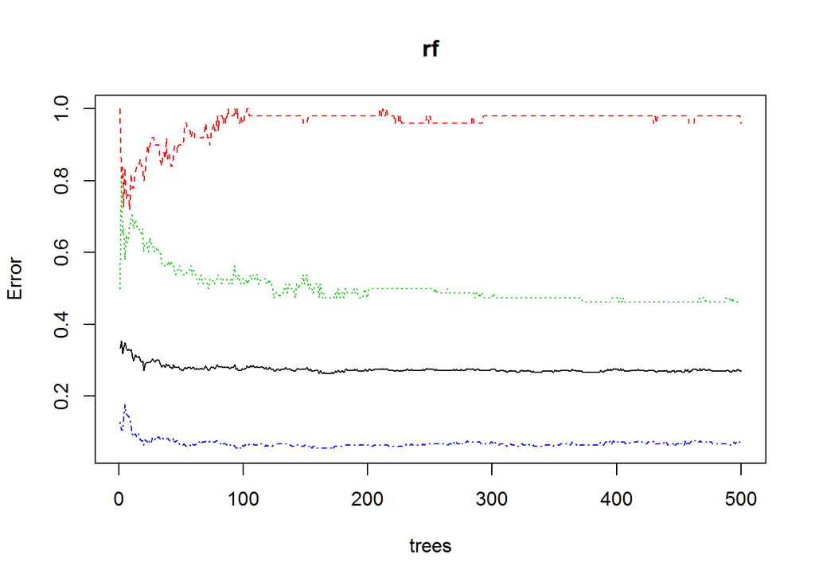

```r
set.seed(42)
rf <- randomForest(delinquency_change ~ ., data = loan_data_labeled[sp, ],
                   nodesize = 30)

# Visualize RF performance
plot(rf)
```

```r
# Training set accuracy
mean(predict(rf, newdata = loan_data_labeled[sp, ]) == loan_data_labeled$delinquency_change[sp])
```

```
## [1] 0.7836412
```

```r
# Testing set accuracy
mean(predict(rf, newdata = loan_data_labeled[!sp, ]) == loan_data_labeled$delinquency_change[!sp])
```

```
## [1] 0.7684211
```

#### The new model reached accuracy rate around 0.768, beat the simple decision tree by 0.02. This is not a major improvement, and it seems very hard to improve the accuracy rate of this model any further. This is very likely to be caused by the limited number of records available in this dataset.

## Conclusion

#### Based on the analysis and statistical modeling, it seems the simple decision tree model has outperformed majority voting benchmark very well, and random forest did not significantly improve the prediction accuracy. Therefore, since Random Forest is much harder to interpret, and hyper-parameter tuning for Random Forest is time consuming, a simple decision tree model might be a better choice for this case analysis.

#### One possible solution to increase the Random Forest model accuracy is to collect more data for the modeling process.